# Lab 6

Blue Team: Matt Lawson, Brandon Bowen, Bing Mitchell, Nick Zimmerman

2/22/2019

```r
flights <- filter(flights, ORIGIN=="DEN" | DEST=="DEN")
flights <- mutate(flights,
  DAY_OF_WEEK = weekdays(as.Date(paste(flights$YEAR, flights$MONTH, flights$DAY_OF_MONTH, sep="-"))))
```

# Importance

The importance of flight delays is to increase the efficiency of the airport. If you are able to figure out the cause of delays you can either prevent the ones you can and increase efficiency or recognize the variables you can’t change and plan accordingly.

The importance of knowing the cause of delays from carrier, weather, NAS or security is important so the DIA can figure out what to fix if he can. If the carrier causes the most delays they can have less flights on a ceartin carrier or if NAS is the reason they can get better workers or try to have a less human error as possible. If the reason is either weather or security which the airport has no real control over then they will have to accept those delays and plan according to them.

```r
days=c("Sunday", "Monday", "Tuesday", "Wednesday", "Thursday", "Friday", "Saturday")
delays <- flights %>%
  filter(!is.na(CARRIER_DELAY)) %>%
  group_by(DAY_OF_WEEK) %>%
  summarize(Carrier=mean(CARRIER_DELAY),Weather=mean(WEATHER_DELAY), NAS=mean(NAS_DELAY), Security=mean(SECURITY_DELAY), Late_Arrival=mean(LATE_AIRCRAFT_DELAY)) %>%
  mutate(DAY_OF_WEEK = factor(DAY_OF_WEEK, levels = days)) %>%
  mutate("Total Delay" = Weather+NAS+Security+Late_Arrival) %>%
  arrange(DAY_OF_WEEK)
```

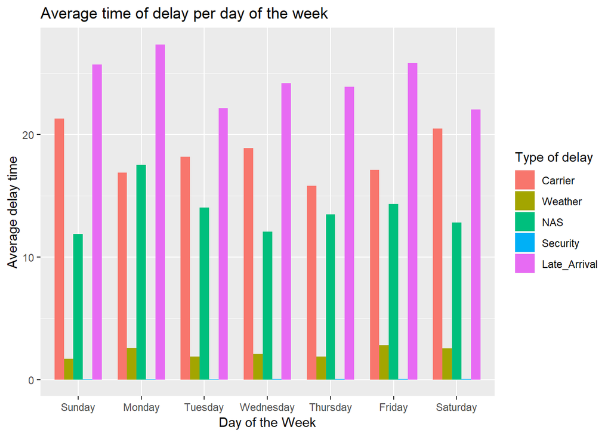

```r
melted <- melt(delays[,c('DAY_OF_WEEK', 'Carrier','Weather','NAS', 'Security', 'Late_Arrival')],id.vars = 1)

ggplot(melted, aes(x=DAY_OF_WEEK, y=value)) +
  geom_bar(aes(fill=variable),width=.75, stat = 'identity', position=position_dodge()) +
  labs(title="Average time of delay per day of the week", x="Day of the Week", y="Average delay time", fill="Type of delay")
```

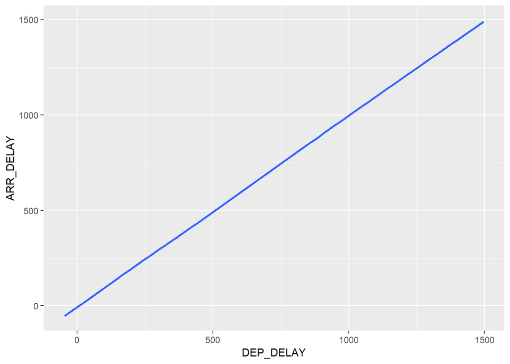

```r
ggplot(flights, aes(x = DEP_DELAY, y = ARR_DELAY))+
  geom_smooth()
```

# Results and Conclusions

We can see that carrier is the main cause for delay between carrier, weather, NAS, and security. Furthermore a signifigant cause for arrival delay is departure delay. As shown by the graph it is clear that as departure delay increases so does arrival delay

# Recomendation

It is recomended that the airport should select which carriers were causing the most arrival delays and have less of them fly out of the Denver airport. The reason this is important becuase if you allow the carriers with consistent delays to continue flying out of the Denver airport it wil keep causing more and more delays for the whole airport. Since one late plane cuases another to be late and another until there are hundreds of late planes throughout the year. Furthermore you want to stop departure delay as much as possible becuase if you are able to depart on time you are more likely to arrive on time.

# Findings

### Matt

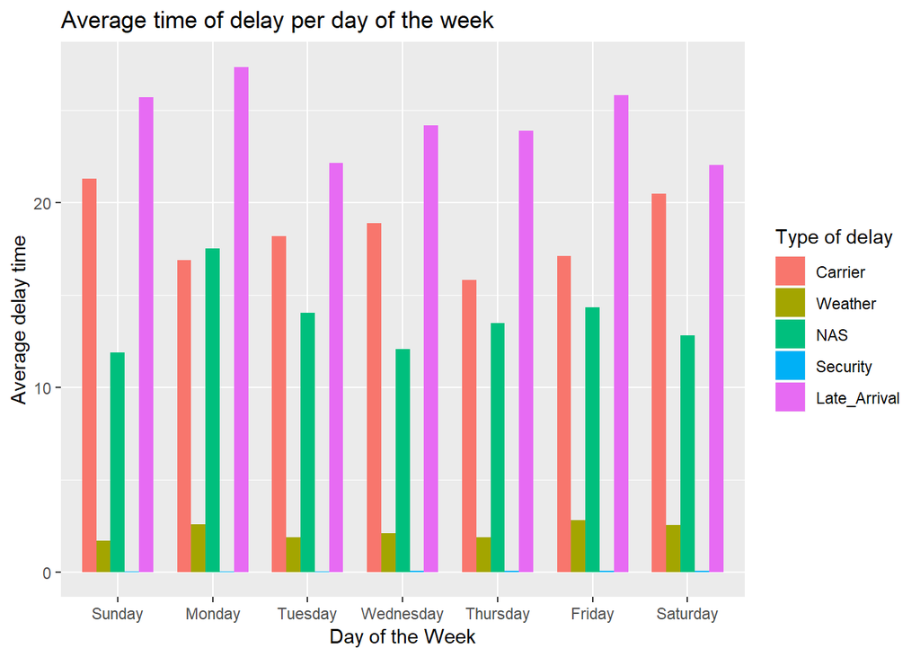

```r
melted <- melt(delays[,c('DAY_OF_WEEK', 'Carrier','Weather','NAS', 'Security', 'Late_Arrival')],id.vars = 1)

ggplot(melted, aes(x=DAY_OF_WEEK, y=value)) +
  geom_bar(aes(fill=variable),width=.75, stat = 'identity', position=position_dodge()) +
  labs(title="Average time of delay per day of the week", x="Day of the Week", y="Average delay time", fill="Type of delay")
```

This plot shows that weather and security delays are mostly constant throughout the week, but Carrier and Late Arrivals seem to vary.

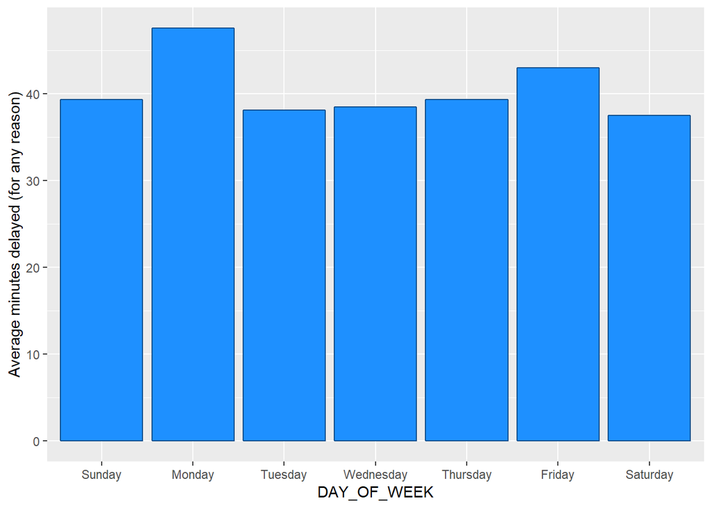

This plot shows that if a flight is delayed, it will be delayed the most on Mondays and Fridays.

### Brandon

```r
delayys <- flights %>%
  filter(ARR_DELAY > 15) %>%
  filter(is.na(ARR_DELAY))
coLongflights <- flights %>%
mutate("delay15" = ARR_DELAY > 15) %>%
mutate("flightt" = AIR_TIME >= 3*60)%>%
mutate("shortflight" = AIR_TIME < 2*60)%>%
filter(!is.na(delay15))
```

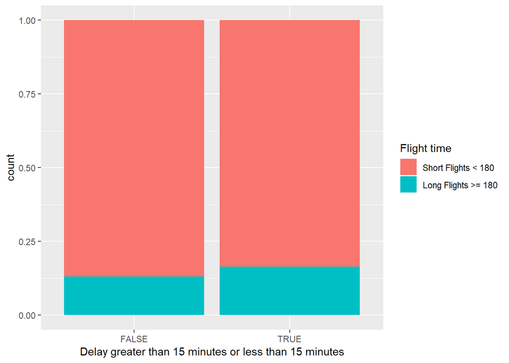

```r
ggplot(coLongflights, aes(x = delay15, fill = flightt )) +
  geom_bar(position = "fill") +
  scale_fill_discrete(name="Flight time",
                      breaks=c(0,1),
                      labels=c("Short Flights < 180 ", "Long Flights >= 180")) +
labs(x = "Delay greater than 15 minutes or less than 15 minutes")
```

This graph shows two things. First it shows that Long flights which were classified asgreater than 3 hours have a higher chance to be delayed compared to flights that were less than 3 hours. Next it shows that short flights are more likely to be on time. Therefore the Denver airport should expect flights longer than 3 hours are more likely to have a 15 or more minute delay than shoter flights.

# Bing

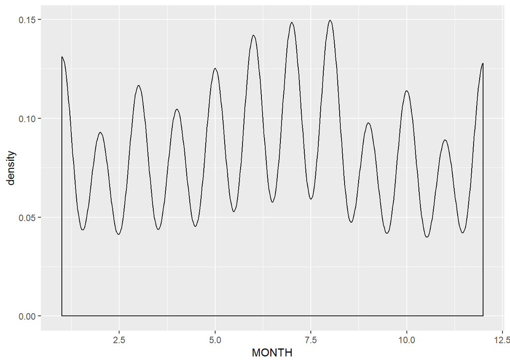

```r
knitr::opts_chunk$set(echo = TRUE)

delayed <- flights %>% filter(DEP_DELAY > 0)

allFlights <- nrow(flights)

total <- nrow(delayed)

ggplot(data = delayed) + geom_density(mapping =aes(x=MONTH))
```

```r
e90 <- flights %>% filter(AIR_TIME < 90)

eTot <- nrow(e90)

d <- e90 %>% filter(DEP_DELAY > 0)

dTot <- nrow(d)

dTot <- dTot / eTot

a90 <- flights %>% filter(AIR_TIME > 89)

aTot <- nrow(a90)

a <- a90 %>% filter(DEP_DELAY > 0)

delTot <- nrow(d)

delTot <- delTot / aTot

percData <- data_frame(Flight_Time = c("Less than 90", "Greater than 90"), Percentage_Late = c(dTot, delTot))
```

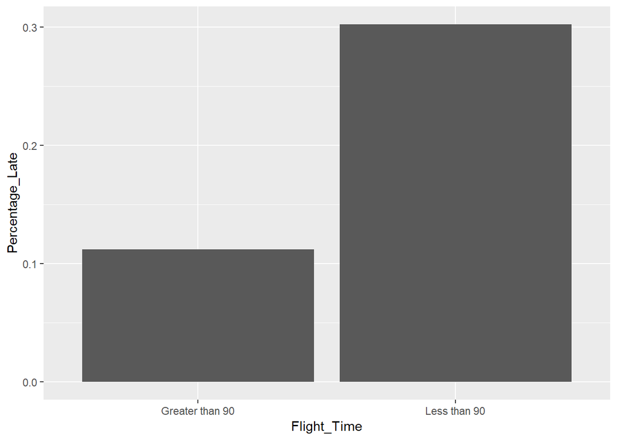

```r
ggplot(data = percData) + geom_col(mapping = aes(x=Flight_Time, y=Percentage_Late))
```

### Nick

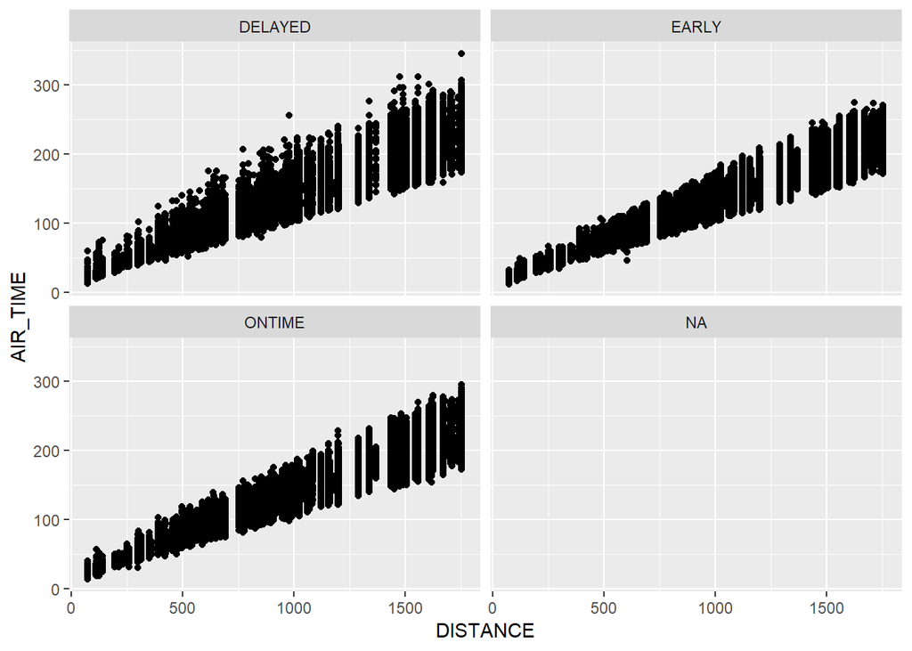

```r
local <- mutate(flights,
                status = ifelse(ARR_DELAY < 0, "EARLY",
                                ifelse(ARR_DELAY < 15, "ONTIME", "DELAYED")))
local <- filter(local,DISTANCE < 2000)
ggplot(data = local) +
  geom_point(mapping = aes(x=DISTANCE, y = AIR_TIME)) +
  facet_wrap(~status)
```

This plot illustrates the of air time of all flights going in and out of DEN. Due to the high overlap of data points I faceted based of status.

# Who Did What

Matt worked on his individual plots and team plot. We didn’t realize one of Matt’s indivdual plots was also a team plot therefore we used them for the same thing so Matt would not be marked down for only one plot and answer.

Brandon worked on his individual plot and answered the team questions. The conclusiion, findings and recomindations

Bing worked on his indivdual plot and answered the team questions. Helped with answering the conclusions and other quesions.

Nick worked on is individual plot